# Project 2: King County Housing Data

Cole Stetson

05/05/2026

# 1 Variable Descriptions

Variable descriptions were obtained from King County, Department of Assessments. All feature engineering should be done in the first code chunks of your document.

- id - Unique ID for each home sold
- date - Date of the home sale
- price - Price of each home sold
- bedrooms - Number of bedrooms
- bathrooms - Number of bathrooms, where .5 accounts for a room with a toilet but no shower
- sqft_living - Square footage of the apartments interior living space
- sqft_lot - Square footage of the land space
- floors - Number of floors
- waterfront - A dummy variable for whether the apartment was overlooking the waterfront or not * 1’s represent a waterfront property, 0’s represent a non-waterfront property
- view - An index from 0 to 4 of how good the view of the property was, 0 - lowest, 4 - highest
- condition - An index from 1 to 5 on the condition of the apartment, 1 - lowest, 4 - highest
- grade - An index from 1 to 13, where 1-3 falls short of building construction and design, 7 has an average level of construction and design, and 11-13 have a high quality level of construction and design.
- sqft_above - The square footage of the interior housing space that is above ground level
- sqft_basement - The square footage of the interior housing space that is below ground level
- yr_built - The year the house was initially built
- yr_renovated - The year of the house’s last renovation
- zipcode - What zipcode area the house is in
- lat - Lattitude
- long - Longitude
- sqft_living15 - The square footage of interior housing living space for the nearest 15 neighbors
- sqft_lot15 - The square footage of the land lots of the nearest 15 neighbors

# 2 Data and Feature Engineering

## 2.1 Data Set (housedata) and Data to send predictions (housedataT)

```r
# Data Set

housedata <- read.csv("https://lasanthi-asu.github.io/STT3851ClassRepo/Rmarkdown/Data/housedata.csv",
                      colClasses = c(id = "character", date = "character",
                                     yr_built = "character", zipcode = "factor", grade = "factor"))

housedata$date <- as.Date(housedata$date, "%Y%m%d")
housedata$waterfront <- factor(housedata$waterfront, labels = c("No", "Yes"))
housedata$condition <- factor(housedata$condition, labels = c("poor", "fair", "average", "good", "very good"))
housedata$yr_renovated <- ifelse(housedata$yr_renovated == 0, housedata$yr_built, housedata$yr_renovated)
housedata$yr_built <- as.Date(ISOdate(housedata$yr_built, 9, 1))  # Complete Year, Sept 1
housedata$yr_renovated <- as.Date(ISOdate(housedata$yr_renovated, 9, 1))  # Last renovated Year, Sept 1
housedata <- housedata[, -1]


# Test Data Set (only use this to send predictions)

#### Perform same steps with test set

housedataT <- read.csv("https://lasanthi-asu.github.io/STT3851ClassRepo/Rmarkdown/Data/housedataTEST.csv",
                      colClasses = c(id = "character", date = "character",
                                     yr_built = "character", zipcode = "factor", grade = "factor"))

housedataT$date <- as.Date(housedataT$date, "%Y%m%d")
housedataT$waterfront <- factor(housedataT$waterfront, labels = c("No", "Yes"))
housedataT$condition <- factor(housedataT$condition, labels = c("poor", "fair", "average", "good", "very good"))
housedataT$yr_renovated <- ifelse(housedataT$yr_renovated == 0, housedataT$yr_built, housedataT$yr_renovated)
housedataT$yr_built <- as.Date(ISOdate(housedataT$yr_built, 9, 1))  # Complete Year, Sept 1
housedataT$yr_renovated <- as.Date(ISOdate(housedataT$yr_renovated, 9, 1))  # Last renovated Year, Sept 1
housedataT <- housedataT[, -1]
```

```r
library(DT)
datatable(housedata[, ], rownames = FALSE)
```

| date | price | bedrooms | bathrooms | sqft_living | sqft_lot | floors | waterfront | view | condition | grade | sqft_above | sqft_basement | yr_built | yr_renovated | zipcode | lat | long | sqft_living15 | sqft_lot15 |
| --- | --- | --- | --- | --- | --- | --- | --- | --- | --- | --- | --- | --- | --- | --- | --- | --- | --- | --- | --- |
| 2014-10-13 | 221900 | 3 | 1 | 1180 | 5650 | 1 | No | 0 | average | 7 | 1180 | 0 | 1955-09-01 | 1955-09-01 | 98178 | 47.5112 | -122.257 | 1340 | 5650 |
| 2014-12-09 | 538000 | 3 | 2.25 | 2570 | 7242 | 2 | No | 0 | average | 7 | 2170 | 400 | 1951-09-01 | 1991-09-01 | 98125 | 47.721 | -122.319 | 1690 | 7639 |
| 2015-02-25 | 180000 | 2 | 1 | 770 | 10000 | 1 | No | 0 | average | 6 | 770 | 0 | 1933-09-01 | 1933-09-01 | 98028 | 47.7379 | -122.233 | 2720 | 8062 |
| 2014-12-09 | 604000 | 4 | 3 | 1960 | 5000 | 1 | No | 0 | very good | 7 | 1050 | 910 | 1965-09-01 | 1965-09-01 | 98136 | 47.5208 | -122.393 | 1360 | 5000 |
| 2015-02-18 | 510000 | 3 | 2 | 1680 | 8080 | 1 | No | 0 | average | 8 | 1680 | 0 | 1987-09-01 | 1987-09-01 | 98074 | 47.6168 | -122.045 | 1800 | 7503 |
| 2014-05-12 | 1225000 | 4 | 4.5 | 5420 | 101930 | 1 | No | 0 | average | 11 | 3890 | 1530 | 2001-09-01 | 2001-09-01 | 98053 | 47.6561 | -122.005 | 4760 | 101930 |
| 2014-06-27 | 257500 | 3 | 2.25 | 1715 | 6819 | 2 | No | 0 | average | 7 | 1715 | 0 | 1995-09-01 | 1995-09-01 | 98003 | 47.3097 | -122.327 | 2238 | 6819 |
| 2015-01-15 | 291850 | 3 | 1.5 | 1060 | 9711 | 1 | No | 0 | average | 7 | 1060 | 0 | 1963-09-01 | 1963-09-01 | 98198 | 47.4095 | -122.315 | 1650 | 9711 |
| 2015-04-15 | 229500 | 3 | 1 | 1780 | 7470 | 1 | No | 0 | average | 7 | 1050 | 730 | 1960-09-01 | 1960-09-01 | 98146 | 47.5123 | -122.337 | 1780 | 8113 |
| 2015-03-12 | 323000 | 3 | 2.5 | 1890 | 6560 | 2 | No | 0 | average | 7 | 1890 | 0 | 2003-09-01 | 2003-09-01 | 98038 | 47.3684 | -122.031 | 2390 | 7570 |

[output cut: 17374 more lines]

# 3 Where to Start

Correlation Matrix maybe helpful.

Here is an example of a correlation matrix with some of the predictors

```r
# Corrplot
library(corrplot)
housedata1 <- housedata[, c(2:7, 9, 12, 13, 17:20)]
cor(housedata1)
```

```
                   price    bedrooms  bathrooms sqft_living     sqft_lot
price         1.00000000  0.31284286 0.52334477  0.70291635  0.088238107
bedrooms      0.31284286  1.00000000 0.52923162  0.59105983  0.030179053
bathrooms     0.52334477  0.52923162 1.00000000  0.75455302  0.082139581
sqft_living   0.70291635  0.59105983 0.75455302  1.00000000  0.166967283
sqft_lot      0.08823811  0.03017905 0.08213958  0.16696728  1.000000000
floors        0.25235756  0.18028523 0.50066694  0.35267511 -0.002951851
view          0.39102268  0.07884375 0.18312596  0.27981310  0.069978368
sqft_above    0.60527752  0.49174312 0.68455295  0.87631944  0.176005462
sqft_basement 0.33122956  0.31056084 0.29077234  0.44288611  0.018691884
lat           0.30948443 -0.01002422 0.02676418  0.05693083 -0.085417697
long          0.02131272  0.13604729 0.22151426  0.23737409  0.225347502
sqft_living15 0.58348082  0.40306677 0.56816564  0.75627424  0.147707827
sqft_lot15    0.08080643  0.02784234 0.08467962  0.17830644  0.727774079
                    floors         view   sqft_above sqft_basement          lat
price          0.252357558  0.391022681  0.605277522    0.33122956  0.309484427
bedrooms       0.180285231  0.078843754  0.491743119    0.31056084 -0.010024220
bathrooms      0.500666944  0.183125959  0.684552945    0.29077234  0.026764178
sqft_living    0.352675112  0.279813103  0.876319445    0.44288611  0.056930825
sqft_lot      -0.002951851  0.069978368  0.176005462    0.01869188 -0.085417697
floors         1.000000000  0.026258735  0.522710921   -0.24145116  0.049952734
view           0.026258735  1.000000000  0.163954243    0.27514730  0.008885553
sqft_above     0.522710921  0.163954243  1.000000000   -0.04379916  0.001422037
sqft_basement -0.241451164  0.275147303 -0.043799158    1.00000000  0.115419784
lat            0.049952734  0.008885553  0.001422037    0.11541978  1.000000000
long           0.125918561 -0.076033506  0.341128260   -0.14261452 -0.133311159
sqft_living15  0.280417017  0.279937620  0.732554007    0.20500421  0.049938206
sqft_lot15    -0.007389463  0.068809179  0.188503973    0.01894595 -0.089826111
                     long sqft_living15   sqft_lot15
price          0.02131272    0.58348082  0.080806426
bedrooms       0.13604729    0.40306677  0.027842339
bathrooms      0.22151426    0.56816564  0.084679619
sqft_living    0.23737409    0.75627424  0.178306444
sqft_lot       0.22534750    0.14770783  0.727774079
floors         0.12591856    0.28041702 -0.007389463
view          -0.07603351    0.27993762  0.068809179
sqft_above     0.34112826    0.73255401  0.188503973
sqft_basement -0.14261452    0.20500421  0.018945951
lat           -0.13331116    0.04993821 -0.089826111
long           1.00000000    0.33399885  0.253890095
sqft_living15  0.33399885    1.00000000  0.184561578
sqft_lot15     0.25389009    0.18456158  1.000000000
```

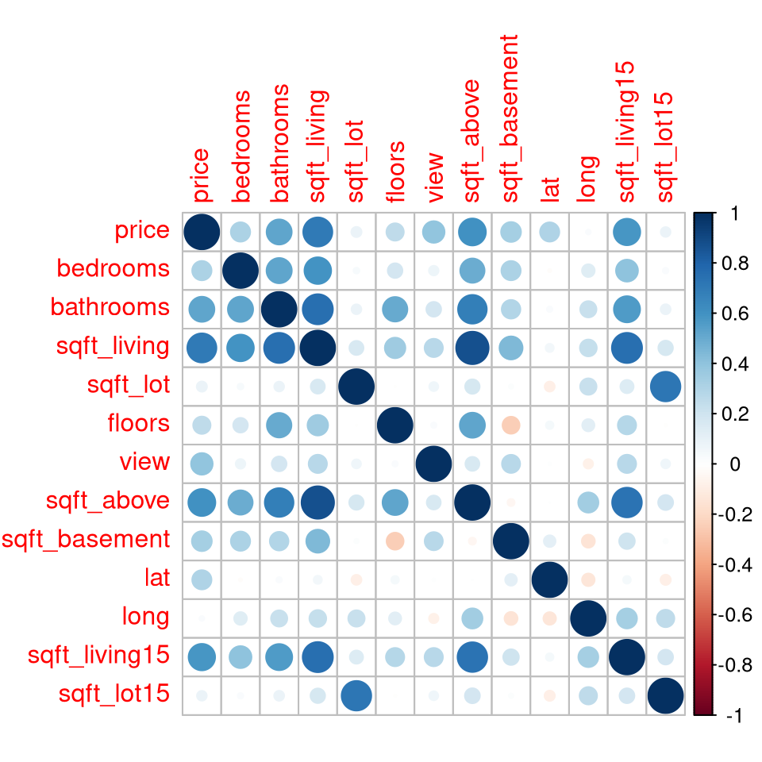

```r
# Corrplot
library(corrplot)
corrplot(cor(housedata1))
```

**Analysis of Correlation Matrix/Plot:**

- Strongest Correlation with Price: sqft_living, sqft_above, sqft_living15, bathrooms, and view.
- Strongest Interaction: All of the sqft variables with each other and with bathrooms/bedrooms.

# 4 Building Models

## 4.1 Most basic model (named mod.zip below).

```r
mod.zip <- lm(price ~ 1, data = housedata)
summary(mod.zip)
```

```
Call:
lm(formula = price ~ 1, data = housedata)

Residuals:
    Min      1Q  Median      3Q     Max
-464367 -219367  -89367  100633 7160633

Coefficients:
            Estimate Std. Error t value Pr(>|t|)
(Intercept)   539367       2804   192.4   <2e-16 ***
---
Signif. codes:  0 '***' 0.001 '**' 0.01 '*' 0.05 '.' 0.1 ' ' 1

Residual standard error: 369700 on 17383 degrees of freedom
```

**EXAMPLE/TEMPLATE**

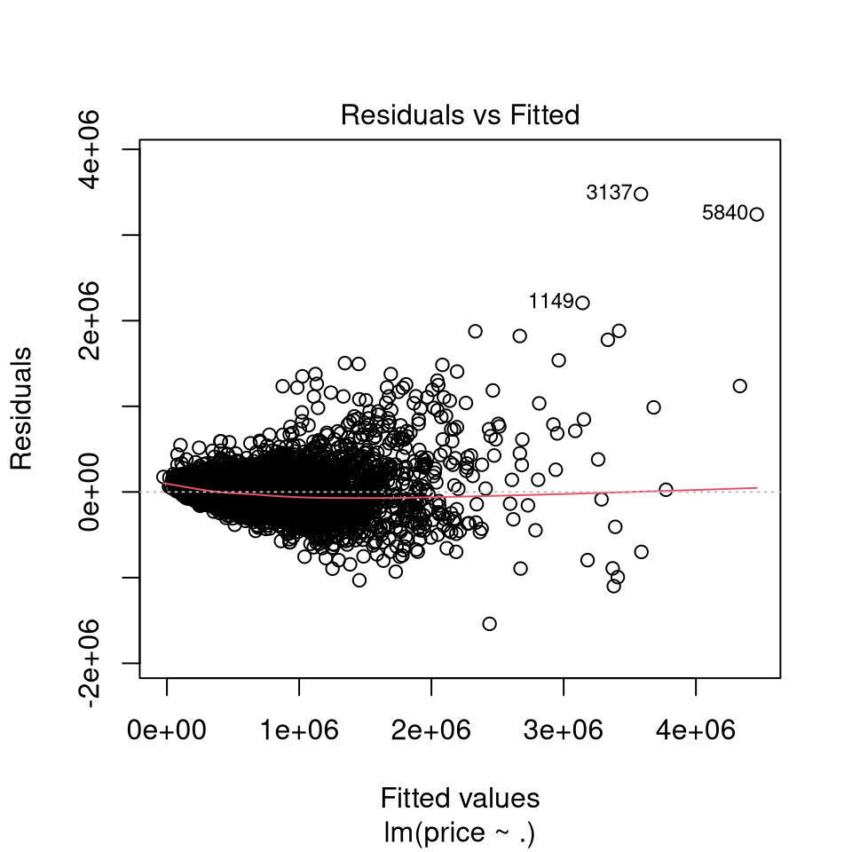

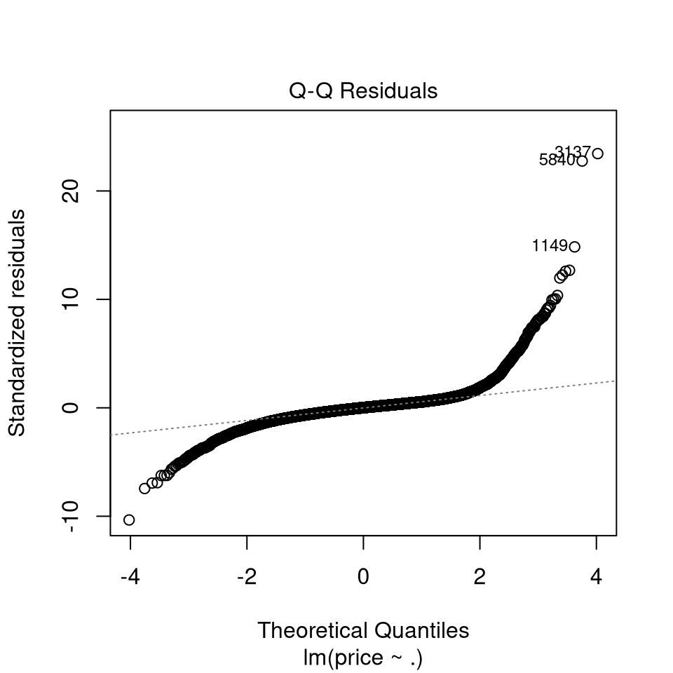

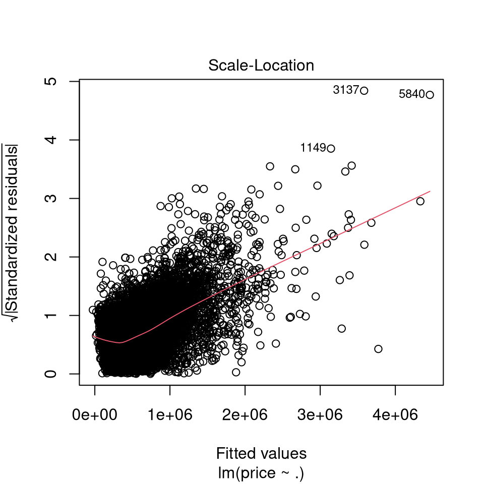

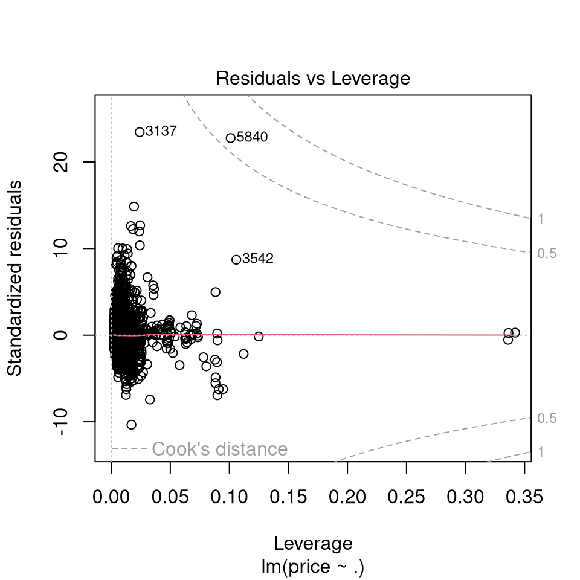

```r
set.seed(1)
mymod1 <- lm(price ~ ., data= housedata)
netnon_dole <- predict(mymod1, newdata= housedataT)
plot(mymod1)
```

**Analysis:** Expected skewness in residuals - needs log transformation on price. Curve in scale-location - needs nonlinear pieces.

**Organizing Data and Variables - Test with lm**

```r
str(housedata)
```

```
'data.frame':   17384 obs. of  20 variables:
 $ date         : Date, format: "2014-10-13" "2014-12-09" ...
 $ price        : num  221900 538000 180000 604000 510000 ...
 $ bedrooms     : int  3 3 2 4 3 4 3 3 3 3 ...
 $ bathrooms    : num  1 2.25 1 3 2 4.5 2.25 1.5 1 2.5 ...
 $ sqft_living  : int  1180 2570 770 1960 1680 5420 1715 1060 1780 1890 ...
 $ sqft_lot     : int  5650 7242 10000 5000 8080 101930 6819 9711 7470 6560 ...
 $ floors       : num  1 2 1 1 1 1 2 1 1 2 ...
 $ waterfront   : Factor w/ 2 levels "No","Yes": 1 1 1 1 1 1 1 1 1 1 ...
 $ view         : int  0 0 0 0 0 0 0 0 0 0 ...
 $ condition    : Factor w/ 5 levels "poor","fair",..: 3 3 3 5 3 3 3 3 3 3 ...
 $ grade        : Factor w/ 12 levels "1","10","11",..: 10 10 9 10 11 3 10 10 10 10 ...
 $ sqft_above   : int  1180 2170 770 1050 1680 3890 1715 1060 1050 1890 ...
 $ sqft_basement: int  0 400 0 910 0 1530 0 0 730 0 ...
 $ yr_built     : Date, format: "1955-09-01" "1951-09-01" ...
 $ yr_renovated : Date, format: "1955-09-01" "1991-09-01" ...
 $ zipcode      : Factor w/ 70 levels "98001","98002",..: 67 56 17 59 38 30 3 69 61 24 ...
 $ lat          : num  47.5 47.7 47.7 47.5 47.6 ...
 $ long         : num  -122 -122 -122 -122 -122 ...
 $ sqft_living15: int  1340 1690 2720 1360 1800 4760 2238 1650 1780 2390 ...
 $ sqft_lot15   : int  5650 7639 8062 5000 7503 101930 6819 9711 8113 7570 ...
```

**Analysis:** There’s a mix of numerical variables, categorical variables, and variables that are labeled “Date”. The four qualitative variables are waterfront, condition, grade, and zipcode. The three date variables are date, yr_built, and yr_renovated. I want to use a Ridge model as my final prediction model because it’s good for highly correlated variables and I see a lot of correlation in the matrix/plot. Because of this I don’t want to actually remove any variables because I know Ridge can use all of them and minimize them accordingly. The date predictors seem of kind of useless right now because a date alone doesn’t really mean anything statistically. Therefore I want to clean up the “Date” predictors so that they are more useful but still included. I want to add a new numeric “age” variable to replace yr_built and date so that the difference (the actual current age of the house) is used. I also want to do the same thing with yr_renovated and add a numeric “age_renovated” variable so that the measure of how currently the house has been renovated is used. I think that both of these engineered features will make a noticeable difference. To futher improve the model, I will test out a bunch of different interaction terms by adding them and then choosing to either keep or remove them after seeing how the MSE changes. To see MSE I am going to split the datatset “housedata” into a training set and test set for cross validation.

```r
library(glmnet)
set.seed(123)

#Adding new predictors to both housedata and housedataT
housedata$age <- 2026 - as.numeric(format(housedata$yr_built, "%Y"))
housedata$age_renovated <- 2026 - as.numeric(format(housedata$yr_renovated, "%Y"))
#Note: I know that we did not learn the "as.numeric(format())" in our class. I looked up online how to extract the year from the date and this is was what I found. This is not completely original work but it was an original idea and I thought using external resources would be okay for this situation.
housedata$log_sqft_living <- log(housedata$sqft_living) #difference between 1000-2000 sqft has bigger impact on price than 5000-6000 sqft
housedata$log_sqft_lot <- log(housedata$sqft_lot) #same concept as last line
housedata$bathrooms_sq <- housedata$bathrooms^2
housedata$living_grade <- housedata$sqft_living * as.numeric(housedata$grade)
#I am using the same "as.numeric() function on the categorical variable grade to make it numerical for interaction. I think house size and quality of construction is an important aspect to capture because some big houses are built poorly.
housedata$living_view <- housedata$sqft_living * housedata$view #big homes that also have a good view have a bigger impact on price
housedata$bed_bath <- housedata$bedrooms * housedata$bathrooms
housedata$age_condition <- housedata$age * as.numeric(housedata$condition)
#using as.numeric() function on condition for same thing. I think that some old houses have been properly maintained or renovated so they shouldn't be as punished for being old.
housedata$rel_living <- housedata$sqft_living / housedata$sqft_living15 #how big a house is in relation to houses around it is also very important. My parents found a good deal on their house in Asheville because its the smallest house in a nice neighborhood.

#Note: I tried a lot of other interaction variables during the process and removed ones I didn't find useful. These are just the ones I want to include for the final model. Im sure that there are some important ones that I am missing. The sqft interactions terms with one another just felt repetitive so I didn't try many out. I wanted to focus on thinking outside the box and find some hidden relationships that could make a big difference.

#Additonal Post-Note: Changing the lambda made a huge difference. Honestly I could've just left every additonal variable I created because the Ridge model with a good lambda would've minmized the less usefull variables anyway.

housedataT$age <- 2026 - as.numeric(format(housedataT$yr_built, "%Y"))
housedataT$age_renovated <- 2026 - as.numeric(format(housedataT$yr_renovated, "%Y"))
housedataT$log_sqft_living <- log(housedataT$sqft_living)
housedataT$log_sqft_lot <- log(housedataT$sqft_lot)
housedataT$bathrooms_sq <- housedataT$bathrooms^2
housedataT$living_grade <- housedataT$sqft_living * as.numeric(housedataT$grade)
housedataT$living_view <- housedataT$sqft_living * housedataT$view
housedataT$bed_bath <- housedataT$bedrooms * housedataT$bathrooms
housedataT$age_condition <- housedataT$age * as.numeric(housedataT$condition)
housedataT$rel_living <- housedataT$sqft_living / housedataT$sqft_living15



#Training Splits for Cross Validation
train <- sample(1:nrow(housedata), nrow(housedata) / 2)
train_data <- housedata[train, ]
test_data  <- housedata[-train, ]


x_train <- model.matrix(price ~ . - date - yr_built - yr_renovated, data = train_data)[, -1]
x_test  <- model.matrix(price ~ . - date - yr_built - yr_renovated, data = test_data)[, -1]

y_train <- log(train_data$price)
y_test  <- log(test_data$price)

grid <- 10^seq(4, -4, length = 200)
#This felt like the biggest piece of my entire model. I had started with the 10^seq(10, -2, length=100) template that we had used in class but I noticed that Lasso and Ridge both picked lambda=0.01. I thought this was a little strange so I wanted to change how I defined the grid and see if it made a difference. I had to look up online what the roles of each number in the function were then once I understood the format I started to change them. This was probably around the 5th setup that I tried and it drastically lowered my MSE so I just stuck with it.
```

**Explanation:** I’m sorry if everything looks a little sloppy. I was trying things quickly

```r
lm_model <- lm(log(price) ~ . - date - yr_built - yr_renovated, data = train_data)

lm_pred <- predict(lm_model, newdata = test_data)

lm_mse <- mean((y_test - lm_pred)^2)

lm_mse
```

```
[1] 0.03084543
```

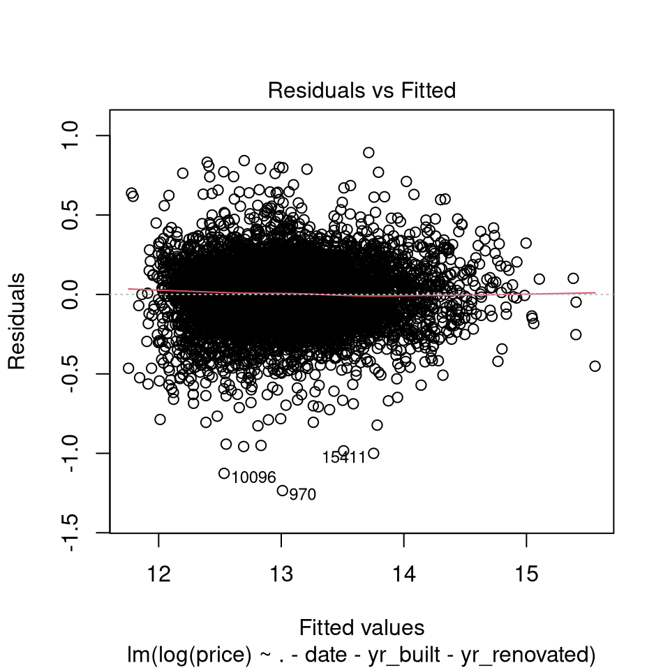

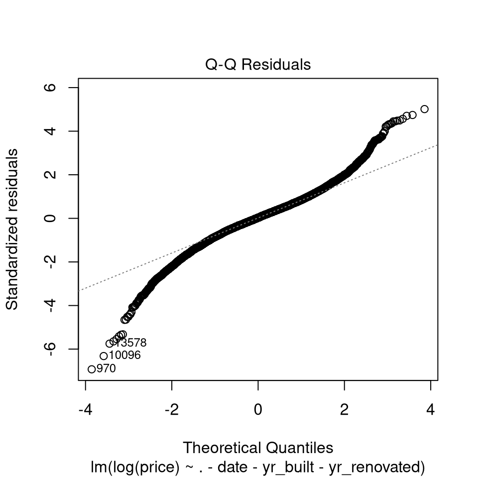

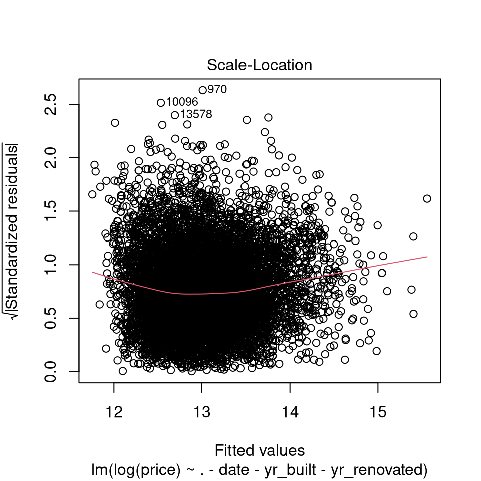

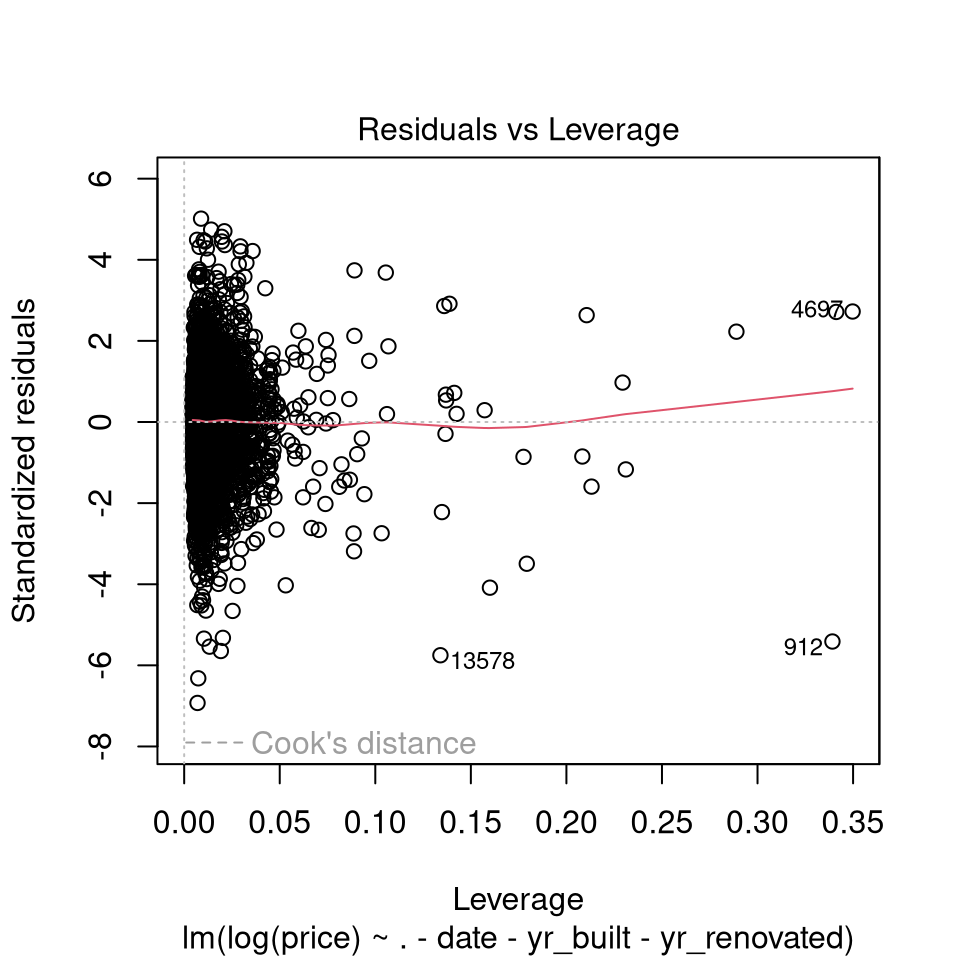

```r
plot(lm_model)
```

**LASSO**

```r
lasso_fit <- glmnet(x_train, y_train, alpha = 1, lambda=grid)
cv_lasso <- cv.glmnet(x_train, y_train, alpha = 1, lambda= grid)

best_lambda_lasso <- cv_lasso$lambda.min
best_lambda_lasso
```

```
[1] 1e-04
```

```r
lasso_model <- glmnet(x_train, y_train, alpha = 1, lambda = best_lambda_lasso)

coef(lasso_model)
```

```
108 x 1 sparse Matrix of class "dgCMatrix"
                              s0
(Intercept)        -9.102419e+01
bedrooms           -1.273919e-03
bathrooms           5.146397e-02
sqft_living         4.694665e-05
sqft_lot            2.565223e-07
floors             -2.788602e-02
waterfrontYes       4.903525e-01
view                6.048259e-02
conditionfair      -2.363511e-02
conditionaverage    1.123881e-02
conditiongood       .
conditionvery good -1.904817e-04
grade10             2.517996e-01
grade11             3.304638e-01
grade12             4.143039e-01
grade13             6.211210e-01
grade3             -1.330072e-01
grade4             -2.561422e-01
grade5             -2.130711e-01
grade6             -1.720850e-01
grade7             -8.102377e-02
grade8              .
grade9              8.825982e-02
sqft_above          1.442802e-06
sqft_basement      -7.664927e-05
zipcode98002        1.761143e-02
zipcode98003       -2.088214e-02
zipcode98004        8.556843e-01
zipcode98005        4.412248e-01
zipcode98006        4.321520e-01
zipcode98007        3.956763e-01
zipcode98008        4.069207e-01
zipcode98010        3.209589e-01
zipcode98011        3.603330e-02
zipcode98014        5.673997e-02
zipcode98019        3.957764e-03
zipcode98022        2.356155e-01
zipcode98023       -8.394583e-02
```

[output cut: 55 more lines]

```
zipcode98199        4.869099e-01
lat                 9.955517e-01
long               -4.367573e-01
sqft_living15       7.565084e-05
sqft_lot15         -2.871402e-07
age                -1.459300e-03
age_renovated      -1.078572e-03
log_sqft_living     2.969546e-01
log_sqft_lot        5.730919e-02
bathrooms_sq        1.923543e-03
living_grade        2.656524e-06
living_view        -9.022882e-07
bed_bath           -5.520159e-03
age_condition       8.088756e-04
rel_living          9.841467e-03
```

```r
lasso_pred <- predict(cv_lasso, s = best_lambda_lasso, newx = x_test)

lasso_mse <- mean((y_test - lasso_pred)^2)
lasso_mse
```

```
[1] 0.03091817
```

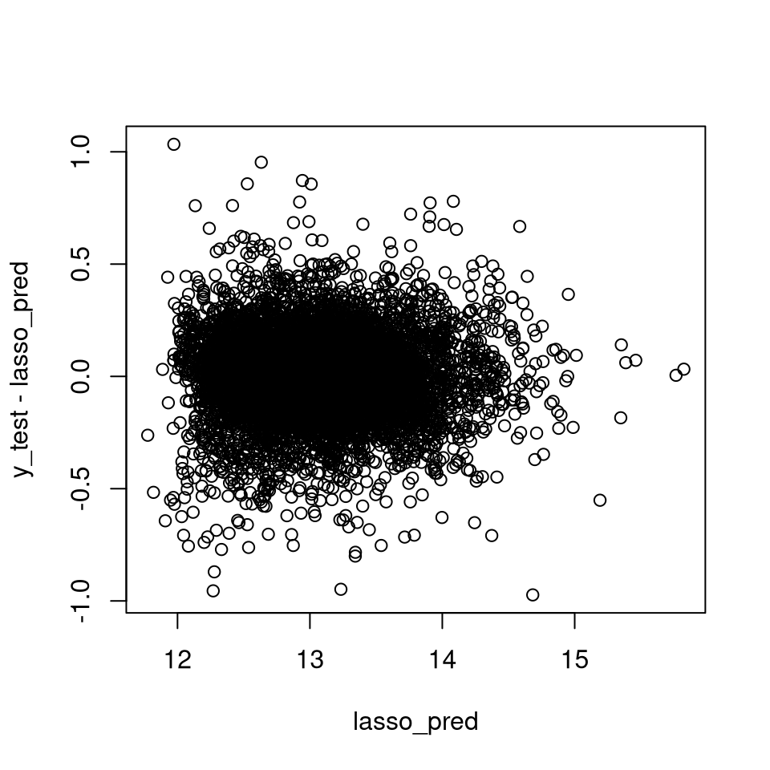

```r
plot(lasso_pred, y_test - lasso_pred)
```

Analysis: Higher MSE than OLS which shows that removing some variables entirely may not be the best idea.

**RIDGE**

```r
library(glmnet)

ridge_fit <- glmnet(x_train, y_train, alpha = 0, lambda=grid)
cv_ridge <- cv.glmnet(x_train, y_train, alpha = 0, lambda= grid)

best_lambda_ridge <- cv_ridge$lambda.min
best_lambda_ridge
```

```
[1] 1e-04
```

```r
ridge_model <- glmnet(x_train, y_train, alpha = 0, lambda = best_lambda_ridge)
```

```r
ridge_pred <- predict(cv_ridge, s = best_lambda_ridge, newx = x_test)

ridge_mse <- mean((y_test - ridge_pred)^2)
ridge_mse
```

```
[1] 0.03084509
```

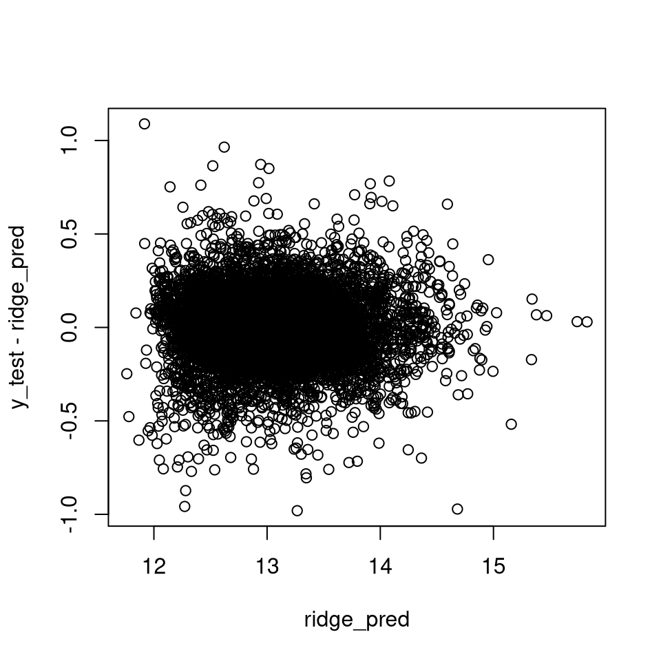

```r
plot(ridge_pred, y_test - ridge_pred)
```

Analysis: Lower MSE than Lasso, most likely works better because of variables being highly correlated. This confirms ideas from Scale-Location plot from OLS.

**MSE Table**

```r
model_results <- data.frame(Model = c("OLS", "LASSO", "Ridge"), Test_MSE = c(lm_mse, lasso_mse, ridge_mse))

model_results
```

```
  Model   Test_MSE
1   OLS 0.03084543
2 LASSO 0.03091817
3 Ridge 0.03084509
```

**Format for Final Prediction “Stetson_Cole”**

```r
x_all <- model.matrix(price ~ . - date - yr_built - yr_renovated, data = housedata)[, -1]
y_all <- log(housedata$price)

cv_ridge_full <- cv.glmnet(x_all, y_all, alpha = 0, lambda = grid)
best_lambda_full <- cv_ridge_full$lambda.min
housedataT_final <- model.matrix(~ . - date - yr_built - yr_renovated, data = housedataT)[, -1]

Stetson_Cole <- predict(cv_ridge_full, s = best_lambda_full, newx = housedataT_final)

Stetson_Cole <- exp(Stetson_Cole)

nrow(housedataT)
```

```
[1] 4229
```

```r
length(Stetson_Cole)
```

```
[1] 4229
```

```r
write.csv(Stetson_Cole, file = "Stetson_Cole.csv", row.names = FALSE)
```